# Women in Parliament - Tidy Data

Joana Jesus

sex 06 dez 2019 (11:33:05)

[figure not shown]

# Objectives

*Explore the geographical and time trends for the percentage of women in national parliaments.*

# Understanding the Data

## The World Bank Data

The raw data for *“Proportion of seats held by women in national parliaments”* includes the percentage of women in parliament (*“single or lower parliamentary chambers only”*) by country (region) and year. It can be downloaded from:

- https://data.worldbank.org/indicator/SG.GEN.PARL.ZS

As part of its “open data” mission the World Bank offers *“free and open access to global development data”* kindly licensed under the “Creative Commons Attribution 4.0 (CC-BY 4.0)”.

## Source Data

The data originates from the “Inter-Parliamentary Union” (IPU)[^ipuwebsite] which provides an *“Archive of statistical data on the percentage of women in national parliaments”* going back to 1997 on a monthly basis:

- http://archive.ipu.org/wmn-e/classif-arc.htm

The World Bank data is for “single or lower parliamentary chambers only”, while the IPU also presents data for “Upper Houses or Senates”. Moreover, the IPU provides the actual numbers used to calculate the percentages (which the World Bank does not).

## Data limitations

Take caution when interpreting these data, as parliamentary systems vary from country to country, and in some cases over time. Some of the issues to consider include:

- Who has, and who does not have, the right to become a Member of Parliament (MP)?
- How does someone become an MP? Through democratic elections? How is “democratic election” defined?
- What is the real power of MPs and their parliament? Can MPs make a difference?

## Data definitions & assumptions

### “Women”

The definition for “women” is not given, so we will assume that it refers to a binary classification for gender (sex).

### “Country (Region)”

The definition of countries and regions can change over time. (e.g. formation of new countries after conflicts, new member states joining a pre-existing collective). How are these changes reflected in the data? How do they affect the interpretation?

## Pro tip

Understand the limitations of your data before anybody else points them out to you.

# About the data file

The data is stored in a file called: `API_SG.GEN.PARL.ZS_DS2_en_csv_v2_511371.csv`

To simplify things we have copied it to `WB-WiP.csv` (which also allows us to maintain the original file in case something goes wrong).

## Pro tip

Always keep a backup copy of the data. Alternatively, set the data file(s) to “read-only” to protect it from being overwritten or modified.

# Importing the data

```r
library(data.table)
library(here)
wip <- fread(here("data", "WB-WiP.csv"),
             skip = 4, header = TRUE,
             check.names = TRUE)
class(wip)
## [1] "data.table" "data.frame"
str(wip)
## Classes 'data.table' and 'data.frame':   264 obs. of  65 variables:
##  $ Country.Name  : chr  "Aruba" "Afghanistan" "Angola" "Albania" ...
##  $ Country.Code  : chr  "ABW" "AFG" "AGO" "ALB" ...
##  $ Indicator.Name: chr  "Proportion of seats held by women in national parliaments (%)" "Proportion of seats held by women in national parliaments (%)" "Proportion of seats held by women in national parliaments (%)" "Proportion of seats held by women in national parliaments (%)" ...
##  $ Indicator.Code: chr  "SG.GEN.PARL.ZS" "SG.GEN.PARL.ZS" "SG.GEN.PARL.ZS" "SG.GEN.PARL.ZS" ...
##  $ X1960         : logi  NA NA NA NA NA NA ...
##  $ X1961         : logi  NA NA NA NA NA NA ...
##  $ X1962         : logi  NA NA NA NA NA NA ...
##  $ X1963         : logi  NA NA NA NA NA NA ...
##  $ X1964         : logi  NA NA NA NA NA NA ...
##  $ X1965         : logi  NA NA NA NA NA NA ...
##  $ X1966         : logi  NA NA NA NA NA NA ...
##  $ X1967         : logi  NA NA NA NA NA NA ...
##  $ X1968         : logi  NA NA NA NA NA NA ...
##  $ X1969         : logi  NA NA NA NA NA NA ...
##  $ X1970         : logi  NA NA NA NA NA NA ...
##  $ X1971         : logi  NA NA NA NA NA NA ...
##  $ X1972         : logi  NA NA NA NA NA NA ...
##  $ X1973         : logi  NA NA NA NA NA NA ...
##  $ X1974         : logi  NA NA NA NA NA NA ...
##  $ X1975         : logi  NA NA NA NA NA NA ...
##  $ X1976         : logi  NA NA NA NA NA NA ...
##  $ X1977         : logi  NA NA NA NA NA NA ...
##  $ X1978         : logi  NA NA NA NA NA NA ...
##  $ X1979         : logi  NA NA NA NA NA NA ...
##  $ X1980         : logi  NA NA NA NA NA NA ...
##  $ X1981         : logi  NA NA NA NA NA NA ...
##  $ X1982         : logi  NA NA NA NA NA NA ...
##  $ X1983         : logi  NA NA NA NA NA NA ...
##  $ X1984         : logi  NA NA NA NA NA NA ...
##  $ X1985         : logi  NA NA NA NA NA NA ...
##  $ X1986         : logi  NA NA NA NA NA NA ...
##  $ X1987         : logi  NA NA NA NA NA NA ...
##  $ X1988         : logi  NA NA NA NA NA NA ...
##  $ X1989         : logi  NA NA NA NA NA NA ...
##  $ X1990         : num  NA 3.7 14.5 28.8 NA ...
##  $ X1991         : logi  NA NA NA NA NA NA ...
##  $ X1992         : logi  NA NA NA NA NA NA ...
##  $ X1993         : logi  NA NA NA NA NA NA ...
##  $ X1994         : logi  NA NA NA NA NA NA ...
##  $ X1995         : logi  NA NA NA NA NA NA ...
##  $ X1996         : logi  NA NA NA NA NA NA ...
##  $ X1997         : num  NA NA 9.5 NA 7.1 ...
##  $ X1998         : num  NA NA 15.5 NA 7.1 ...
##  $ X1999         : num  NA NA 15.5 5.2 7.1 ...
##  $ X2000         : num  NA NA 15.5 5.2 7.1 ...
##  $ X2001         : num  NA NA 15.5 5.7 14.3 ...
##  $ X2002         : num  NA NA 15.5 5.7 14.3 ...
##  $ X2003         : num  NA NA 15.5 5.7 14.3 ...
##  $ X2004         : num  NA NA 15 6.4 14.3 ...
##  $ X2005         : num  NA 27.3 15 7.1 28.6 ...
##  $ X2006         : num  NA 27.3 15 7.1 28.6 ...
##  $ X2007         : num  NA 27.7 15 7.1 28.6 ...
##  $ X2008         : num  NA 27.7 37.3 7.1 25 ...
##  $ X2009         : num  NA 27.3 38.6 16.4 35.7 ...
##  $ X2010         : num  NA 27.7 38.6 16.4 35.7 ...
##  $ X2011         : num  NA 27.7 38.2 15.7 50 ...
##  $ X2012         : num  NA 27.7 34.1 15.7 50 ...
##  $ X2013         : num  NA 27.7 34.1 17.9 50 ...
##  $ X2014         : num  NA 27.7 36.8 20 50 ...
##  $ X2015         : num  NA 27.7 36.8 20.7 39.3 ...
##  $ X2016         : num  NA 27.7 36.8 22.9 32.1 ...
##  $ X2017         : num  NA 27.7 38.2 27.9 32.1 ...
##  $ X2018         : num  NA 27.7 30.5 27.9 32.1 ...
##  $ X2019         : logi  NA NA NA NA NA NA ...
##  $ V65           : logi  NA NA NA NA NA NA ...
##  - attr(*, ".internal.selfref")=<externalptr>
```

# Data Wrangling Aims

##Superfluous columns

```r
wip[, .N, by=.(V65)]
```

```
##    V65   N
## 1:  NA 264
```

##Removing Columns

```r
wip[, c("Indicator.Name", "Indicator.Code", "V65"):=NULL]

setnames(wip, c("Country.Name", "Country.Code"), c("Country", "Code"))

head(names(wip))
```

```
## [1] "Country" "Code"    "X1960"   "X1961"   "X1962"   "X1963"
```

```r
tail(names(wip))
```

```
## [1] "X2014" "X2015" "X2016" "X2017" "X2018" "X2019"
```

##Reshape to long format

```r
WP <- melt(wip,id.vars = c("Country", "Code"), measure = patterns("^X"), variable.name = "YearC", value.name = c("pctWiP"), na.rm = TRUE)
melt.data.table(WP)
```

```
##                    Country Code YearC variable     value
##    1:          Afghanistan  AFG X1990   pctWiP  3.700000
##    2:               Angola  AGO X1990   pctWiP 14.500000
##    3:              Albania  ALB X1990   pctWiP 28.800000
##    4:           Arab World  ARB X1990   pctWiP  3.891439
##    5: United Arab Emirates  ARE X1990   pctWiP  0.000000
##   ---
## 5105:                Samoa  WSM X2018   pctWiP 10.000000
## 5106:          Yemen, Rep.  YEM X2018   pctWiP  0.000000
## 5107:         South Africa  ZAF X2018   pctWiP 42.300000
## 5108:               Zambia  ZMB X2018   pctWiP 18.000000
## 5109:             Zimbabwe  ZWE X2018   pctWiP 31.500000
```

```r
WP
```

```
##                    Country Code YearC    pctWiP
##    1:          Afghanistan  AFG X1990  3.700000
##    2:               Angola  AGO X1990 14.500000
##    3:              Albania  ALB X1990 28.800000
##    4:           Arab World  ARB X1990  3.891439
##    5: United Arab Emirates  ARE X1990  0.000000
##   ---
## 5105:                Samoa  WSM X2018 10.000000
## 5106:          Yemen, Rep.  YEM X2018  0.000000
## 5107:         South Africa  ZAF X2018 42.300000
## 5108:               Zambia  ZMB X2018 18.000000
## 5109:             Zimbabwe  ZWE X2018 31.500000
```

##Final tweaks to WP

```r
WP[, `:=`(Year=as.numeric(gsub("[^[:digit:].]", "", YearC)), Ratio = (100-pctWiP)/pctWiP)][, YearC:=NULL]

setcolorder(WP, c("Country", "Code", "Year", "pctWiP", "Ratio"))

WP
```

```
##                    Country Code Year    pctWiP     Ratio
##    1:          Afghanistan  AFG 1990  3.700000 26.027027
##    2:               Angola  AGO 1990 14.500000  5.896552
##    3:              Albania  ALB 1990 28.800000  2.472222
##    4:           Arab World  ARB 1990  3.891439 24.697433
##    5: United Arab Emirates  ARE 1990  0.000000       Inf
##   ---
## 5105:                Samoa  WSM 2018 10.000000  9.000000
## 5106:          Yemen, Rep.  YEM 2018  0.000000       Inf
## 5107:         South Africa  ZAF 2018 42.300000  1.364066
## 5108:               Zambia  ZMB 2018 18.000000  4.555556
## 5109:             Zimbabwe  ZWE 2018 31.500000  2.174603
```

#Exploratory analysis

```r
WP[Country %in% "Portugal"]
```

```
##      Country Code Year pctWiP     Ratio
##  1: Portugal  PRT 1990    7.6 12.157895
##  2: Portugal  PRT 1997   13.0  6.692308
##  3: Portugal  PRT 1998   13.0  6.692308
##  4: Portugal  PRT 1999   18.7  4.347594
##  5: Portugal  PRT 2000   17.4  4.747126
##  6: Portugal  PRT 2001   18.7  4.347594
##  7: Portugal  PRT 2002   19.1  4.235602
##  8: Portugal  PRT 2003   19.1  4.235602
##  9: Portugal  PRT 2004   19.1  4.235602
## 10: Portugal  PRT 2005   21.3  3.694836
## 11: Portugal  PRT 2006   21.3  3.694836
## 12: Portugal  PRT 2007   28.3  2.533569
## 13: Portugal  PRT 2008   28.3  2.533569
## 14: Portugal  PRT 2009   27.4  2.649635
## 15: Portugal  PRT 2010   27.4  2.649635
## 16: Portugal  PRT 2011   28.7  2.484321
## 17: Portugal  PRT 2012   28.7  2.484321
## 18: Portugal  PRT 2013   28.7  2.484321
## 19: Portugal  PRT 2014   31.3  2.194888
## 20: Portugal  PRT 2015   34.8  1.873563
## 21: Portugal  PRT 2016   34.8  1.873563
## 22: Portugal  PRT 2017   34.8  1.873563
## 23: Portugal  PRT 2018   34.8  1.873563
##      Country Code Year pctWiP     Ratio
```

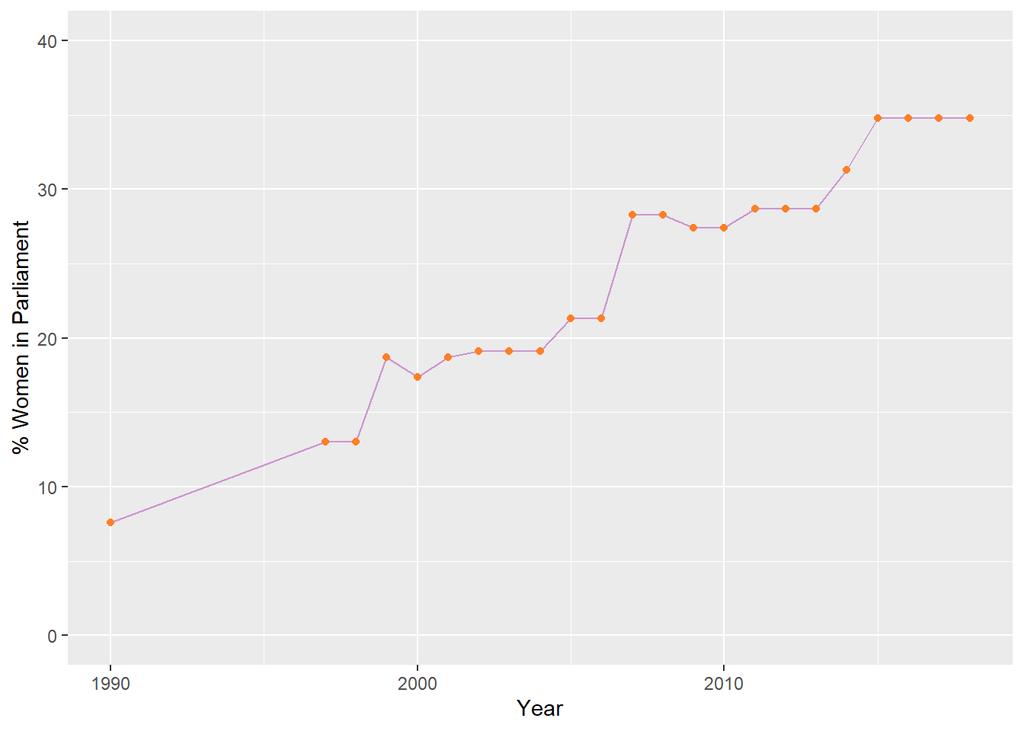

```r
library(ggplot2)

library(magrittr)

WP[Country %in% "Portugal"] %>% ggplot(aes(Year, pctWiP)) + geom_line(colour="plum3") + geom_point(colour="chocolate1") + scale_y_continuous(limits=c(0, 40)) + ylab("% Women in Parliament")
```

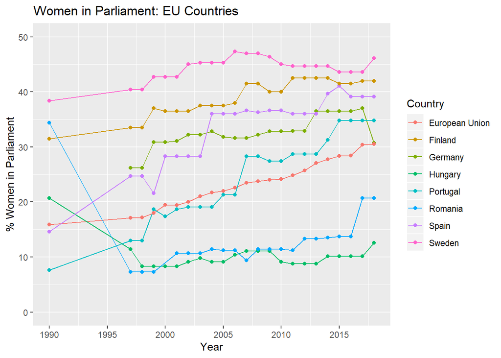

[figure not shown]

```r
WP[Country %in% c("Portugal", "Sweden", "Spain", "Hungary", "Romania", "Finland", "Germany", "European Union")] %>% ggplot(aes(Year, pctWiP, colour=Country)) + geom_line() + geom_point() + scale_x_continuous(breaks=seq(1990, 2020, 5)) + scale_y_continuous(limits=c(0,50), breaks=seq(0, 50, by=10)) + ggtitle("Women in Parliament: EU Countries") + ylab("% Women in Parliament")
```